# Problem Set 4

Author

Lauren Nagle

Published

November 20, 2026

**GitHub repo:** https://github.com/laurengnagle/ec422_ps4_nagle

## ARIMA vs. ETS

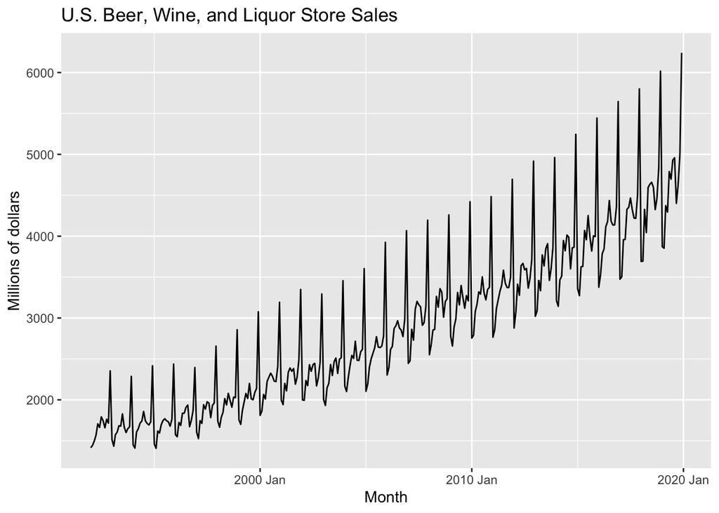

```r
liquor <- read_csv("data/MRTSSM4453USN.csv", na = ".",
  col_types = cols(observation_date = col_date(format = "%Y-%m-%d"),
                   MRTSSM4453USN = col_double())) |>
  transmute(Month = yearmonth(observation_date), sales = MRTSSM4453USN) |>
  as_tsibble(index = Month) |>
  filter(Month <= yearmonth("2019 Dec"))

liquor |>
  autoplot(sales) +
  labs(title = "U.S. Beer, Wine, and Liquor Store Sales",
       x = "Month", y = "Millions of dollars")
```

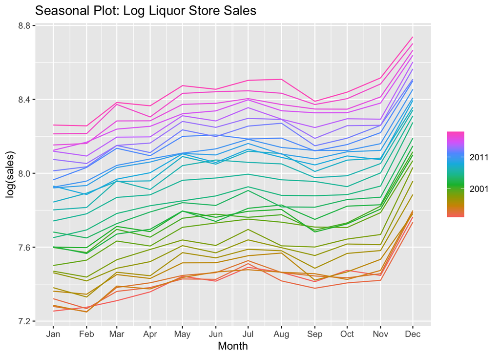

```r
liquor |>
  gg_season(log(sales)) +
  labs(title = "Seasonal Plot: Log Liquor Store Sales",
       x = "Month", y = "log(sales)")
```

Liquor store sales trend steadily upward, rising from roughly $1,500–2,000 million per month in 1992 to roughly $4,000–5,000 million by 2019. The seasonal pattern is strong: December is by far the highest month, likely due to holiday purchases, while January and February are the lowest. The December spikes get noticeably larger as the level of sales rises, so the seasonal swings are proportional to the level (multiplicative). Taking logs converts this into roughly constant-sized swings, which makes the seasonality easier to model.

```r
liquor_fit <- liquor |>
  model(arima = ARIMA(log(sales)),
        ets = ETS(log(sales)))
liquor_fit |> select(arima) |> report()
```

```
Series: sales
Model: ARIMA(1,0,2)(2,1,1)[12] w/ drift
Transformation: log(sales)

Coefficients:
         ar1      ma1     ma2    sar1     sar2     sma1  constant
      0.8948  -0.7374  0.2477  0.3679  -0.2334  -0.8845    0.0036
s.e.  0.0355   0.0697  0.0623  0.0668   0.0665   0.0468    0.0001

sigma^2 estimated as 0.0005469:  log likelihood=752.43
AIC=-1488.85   AICc=-1488.4   BIC=-1458.61
```

```r
liquor_fit |> select(ets) |> report()
```

```
Series: sales
Model: ETS(A,A,A)
Transformation: log(sales)
  Smoothing parameters:
    alpha = 0.3296099
    beta  = 0.007560263
    gamma = 0.0001765132

  Initial states:
     l[0]         b[0]      s[0]      s[-1]        s[-2]       s[-3]      s[-4]
 7.412219 0.0007608238 0.3263441 0.03153301 -0.004849389 -0.03530501 0.02512163
      s[-5]      s[-6]      s[-7]       s[-8]      s[-9]     s[-10]     s[-11]
 0.05558624 0.01219515 0.02503206 -0.06088935 -0.0607952 -0.1578065 -0.1561667

  sigma^2:  7e-04

      AIC      AICc       BIC
-489.1517 -487.2272 -424.2608
```

fable chose ARIMA(1,0,2)(2,1,1)[12] with drift and ETS(A,A,A). The ARIMA applies no regular difference (d = 0) but one seasonal difference (D = 1), so it models the 12-month change in log sales; the drift term captures the upward trend. The ETS model has additive error, additive (undamped) trend, and additive seasonality. Because it is fit to log sales, additive seasonality in logs implies multiplicative seasonality in levels.

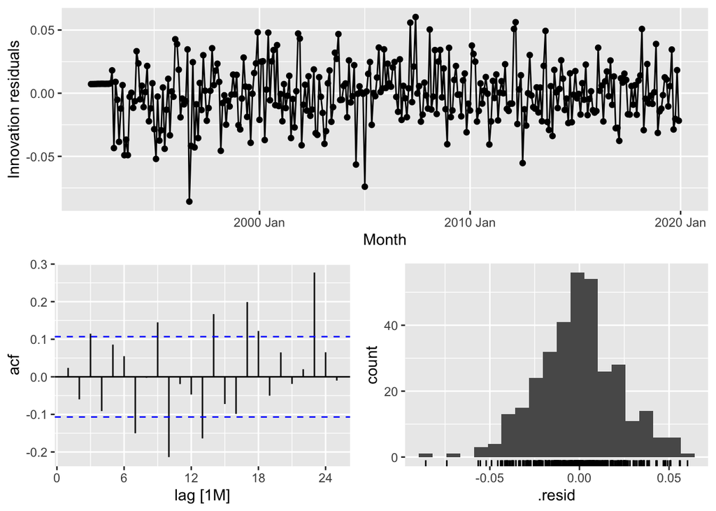

```r
liquor_fit |> select(arima) |> gg_tsresiduals()
```

```r
liquor_fit |>
  select(arima) |>
  augment() |>
  features(.innov, ljung_box, lag = 24, dof = 6)
```

```
# A tibble: 1 × 3
  .model lb_stat lb_pvalue
  <chr>    <dbl>     <dbl>
1 arima     120.         0
```

The ARIMA residuals look roughly centered at zero with stable variance and a roughly normal histogram, but the ACF shows several significant spikes (notably near lags 9–10 and 23–24). The Ljung–Box test at lag 24 (dof = 6) gives Q = 120 with p ≈ 0, so we reject that the residuals are white noise: there is remaining structure the model hasn’t captured. This doesn’t mean the model will forecast poorly, which the horse race tests.

**Horse race.** The sample has 336 months (Jan 1992–Dec 2019). With a first training sample of 120 months, `stretch_tsibble` creates 336 − 120 + 1 = 217 training samples; we drop the last one (ending Dec 2019) because there is no actual value to compare its forecast to, leaving **216 forecast origins**. The first forecast is for January 2002 and the last is for December 2019.

```r
liquor_cv_fc <- readRDS("results/liquor_cv_fc.rds")
liquor_cv_fc |>
  accuracy(liquor, measures = list(RMSE = RMSE, MAE = MAE)) |>
  knitr::kable(digits = 2)
```

| .model | .type | RMSE | MAE |
| --- | --- | --- | --- |
| arima | Test | 81.43 | 65.65 |
| ets | Test | 94.35 | 72.31 |
| snaive | Test | 161.26 | 136.63 |

ARIMA is the most accurate model (RMSE 81.43, MAE 65.65), followed by ETS (94.35, 72.31), with the seasonal naive benchmark far behind (161.26, 136.63). RMSE and MAE agree on the ranking, and both ARIMA and ETS cut the benchmark’s errors roughly in half.

```r
liquor_errs <- liquor_cv_fc |>
  as_tibble() |>
  left_join(as_tibble(liquor) |> select(Month, actual = sales), by = "Month") |>
  mutate(e = actual - .mean) |>
  select(Month, .model, e) |>
  pivot_wider(names_from = .model, values_from = e)

forecast::dm.test(liquor_errs$arima, liquor_errs$ets, h = 1, power = 2)
```

```
    Diebold-Mariano Test

data:  liquor_errs$arimaliquor_errs$ets
DM = -2.9062, Forecast horizon = 1, Loss function power = 2, p-value =
0.004042
alternative hypothesis: two.sided
```

```r
forecast::dm.test(liquor_errs$arima, liquor_errs$snaive, h = 1, power = 2)
```

```
    Diebold-Mariano Test

data:  liquor_errs$arimaliquor_errs$snaive
DM = -10.755, Forecast horizon = 1, Loss function power = 2, p-value <
2.2e-16
alternative hypothesis: two.sided
```

ARIMA vs. ETS: DM = −2.91, p = 0.004. ARIMA vs. the seasonal random walk: DM = −10.76, p < 2.2e−16. The negative statistics mean ARIMA has lower squared errors in both cases, and both differences are statistically significant at the 1% level. ARIMA’s advantage over ETS is real rather than noise, so the liquor chain should use the ARIMA model.

## Forecast Combination

```r
liquor_combo_fc <- readRDS("results/liquor_combo_fc.rds")
liquor_combo_fc |>
  accuracy(liquor, measures = list(RMSE = RMSE, MAE = MAE)) |>
  knitr::kable(digits = 2)
```

| .model | .type | RMSE | MAE |
| --- | --- | --- | --- |
| arima | Test | 81.43 | 65.65 |
| combo | Test | 85.19 | 66.77 |
| ets | Test | 94.35 | 72.31 |
| snaive | Test | 161.26 | 136.63 |

```r
cor(liquor_errs$arima, liquor_errs$ets)
```

```
[1] 0.8782934
```

The equal-weight combination (RMSE 85.19, MAE 66.77) beats ETS but is worse than ARIMA alone on both metrics. The correlation between the ARIMA and ETS forecast errors is 0.88, so the two models tend to make the same mistakes and averaging cancels out little error. Combined with the DM test showing that ARIMA is significantly more accurate than ETS, equal weights drag the forecast toward the weaker model. Combining helps most when models are similarly accurate and their errors are less correlated; neither condition holds here.

## VAR vs. BVAR

We produce 120 one-quarter-ahead forecasts for each variable; the first is for 1990 Q1 and the last is for 2019 Q4.

```r
readRDS("results/var_results.rds") |> knitr::kable(digits = 3)
```

| Variable | VAR(1) | VAR(4) | BVAR(4), lambda = 0.3 | BVAR(4), lambda = 0.05 |
| --- | --- | --- | --- | --- |
| gdp | 0.513 | 0.569 | 0.539 | 0.567 |
| cons | 0.460 | 0.527 | 0.486 | 0.495 |
| inv | 2.493 | 2.521 | 2.385 | 2.698 |
| emp | 0.196 | 0.228 | 0.211 | 0.315 |
| infl | 0.208 | 0.207 | 0.197 | 0.330 |
| unrate | 0.199 | 0.215 | 0.203 | 0.216 |
| ffr | 0.390 | 0.497 | 0.414 | 0.358 |
| gs10 | 0.361 | 0.379 | 0.359 | 0.362 |

**VAR(1) vs. VAR(4).** The VAR(1) forecasts better for 7 of the 8 variables; only inflation is (marginally) better with the VAR(4). Although the VAR(4) nests the VAR(1), it estimates 33 coefficients per equation (264 in total) from as few as 120 observations. Most of the extra lag coefficients are probably close to zero, but OLS estimates them with noise that feeds directly into the forecasts. The smaller model accepts a little bias in exchange for much lower variance.

**BVAR(4), λ = 0.3 vs. OLS VAR(4).** The BVAR is more accurate for all 8 variables. The two models have the same variables and lags, so the difference comes entirely from the Minnesota prior shrinking the coefficients toward zero, which reduces estimation noise without dropping any lags.

**BVAR(4), λ = 0.3 vs. VAR(1).** Mixed: the VAR(1) wins for 5 variables (gdp, cons, emp, unrate, ffr) and the BVAR for 3 (inv, infl, gs10). The VAR(1) is itself a crude form of shrinkage, setting lags 2–4 exactly to zero, and here it works about as well as the smoother Bayesian shrinkage.

**λ = 0.05.** Much worse than λ = 0.3 for 7 of 8 variables (e.g., emp 0.315 vs. 0.211, infl 0.330 vs. 0.197); only ffr improves. This prior is so tight that it pushes forecasts toward the historical mean and throws away real dynamics, so it is possible to shrink too much.

**Is the winner’s RMSE a fair estimate?** No. If we chose the winner from this table, we would be picking it because it did best on this exact evaluation sample, after comparing several models and λ values. Part of that edge is luck, so the winner’s RMSE overstates how accurately it will forecast in the future (selection bias, or the “winner’s curse”). A fair estimate requires a fresh holdout sample that was not used to choose the model.

```r
dm_var <- readRDS("results/dm_var.rds")
dm_var$gdp
```

```
    Diebold-Mariano Test

data:  e_var4e_bvar
DM = 2.1366, Forecast horizon = 1, Loss function power = 2, p-value =
0.03468
alternative hypothesis: two.sided
```

```r
dm_var$ffr
```

```
    Diebold-Mariano Test

data:  e_var4_ffre_bvar_ffr
DM = 1.9999, Forecast horizon = 1, Loss function power = 2, p-value =
0.04779
alternative hypothesis: two.sided
```

For GDP growth, DM = 2.14 (p = 0.035); for the federal funds rate, DM = 2.00 (p = 0.048). The positive statistics mean the VAR(4) has larger squared errors, so the BVAR is significantly more accurate for both variables at the 5% level (though not at 1%). This confirms that shrinkage genuinely improves on the unrestricted VAR(4). The evidence is only moderate, however, and I chose ffr because it had the largest RMSE gap, so it is a favorable case. Many of the smaller differences in the table (e.g., BVAR vs. VAR(1)) are likely not statistically significant, so those rankings should be read with caution.

## Factor Model

```r
md_raw <- read_csv("data/fredmd_2026-09.csv", show_col_types = FALSE)
tcode <- unlist(md_raw[1, -1])
md <- md_raw[-1, ] |> mutate(date = as.Date(sasdate, "%m/%d/%Y"))

transform_series <- function(x, code) {
  d <- function(v) c(NA, diff(v))
  switch(as.character(code),
         "1" = x, "2" = d(x), "3" = d(d(x)), "4" = log(x),
         "5" = 100 * d(log(x)), "6" = 100 * d(d(log(x))),
         "7" = d(x / dplyr::lag(x) - 1))
}

fm <- map2_dfc(md[names(tcode)], tcode, transform_series) |>
  mutate(date = md$date, .before = 1) |>
  filter(date >= as.Date("1960-03-01"), date <= as.Date("2019-12-01"))
fm <- fm[, colSums(is.na(fm)) == 0]
dim(fm)
```

```
[1] 718 122
```

```r
tcode[c("INDPRO", "PAYEMS", "CPIAUCSL", "FEDFUNDS")]
```

```
  INDPRO   PAYEMS CPIAUCSL FEDFUNDS
       5        5        6        2
```

INDPRO and PAYEMS (code 5) enter as monthly growth rates (100 × Δlog). CPIAUCSL (code 6) enters as the change in monthly inflation (100 × Δ²log). FEDFUNDS (code 2) enters as a first difference in percentage points. The funds rate is treated differently because it is already a rate measured in percent: a log growth rate of an interest rate isn’t meaningful and blows up near zero (as in 2009–2015), whereas industrial production is a trending level that grows roughly exponentially, so its log difference is a natural percent growth rate.

```r
Z <- fm |> select(-date) |> as.matrix()
pc <- prcomp(scale(Z))
summary(pc)$importance[, 1:5]
```

```
                            PC1      PC2      PC3      PC4      PC5
Standard deviation     4.258002 2.993839 2.923106 2.597224 2.295261
Proportion of Variance 0.149840 0.074070 0.070620 0.055750 0.043540
Cumulative Proportion  0.149840 0.223910 0.294530 0.350280 0.393820
```

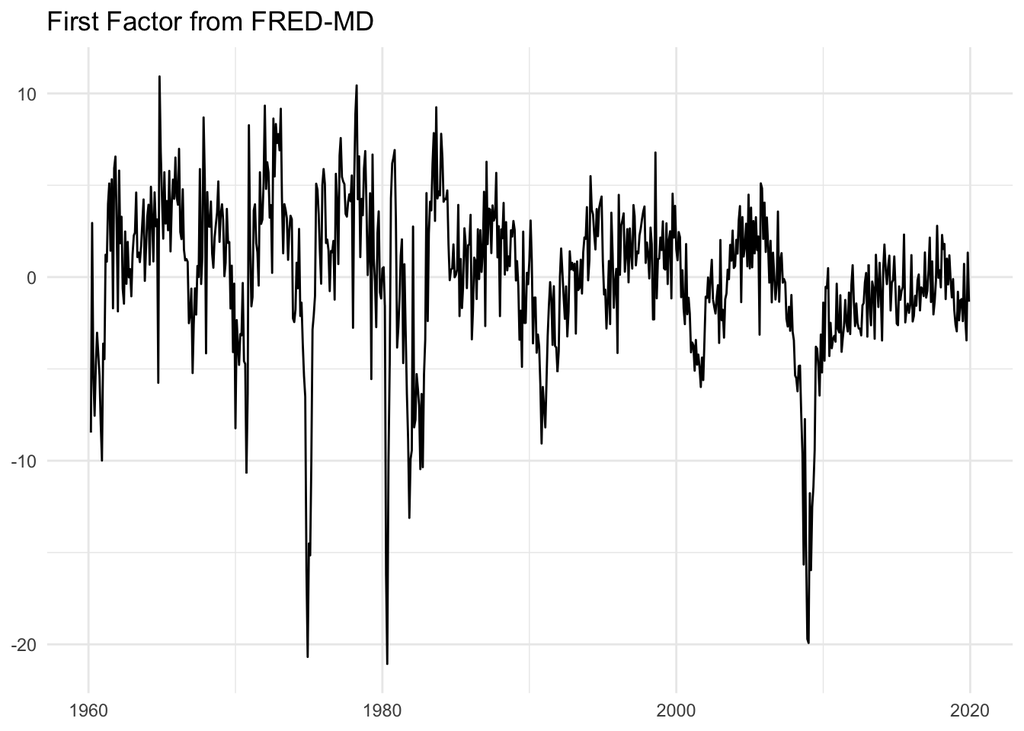

```r
F1 <- pc$x[, 1] * sign(cor(pc$x[, 1], fm$INDPRO))
tibble(date = fm$date, F1 = F1) |>
  ggplot(aes(date, F1)) +
  geom_line() +
  labs(title = "First Factor from FRED-MD", x = NULL, y = NULL) +
  theme_minimal()
```

```r
sort(abs(cor(pc$x[, 1], Z))[1, ], decreasing = TRUE)[1:8]
```

```
   PAYEMS IPMANSICS    USGOOD    INDPRO    MANEMP   IPFPNSS    CUMFNS   DMANEMP
0.8415788 0.8404473 0.8390159 0.8219976 0.8028499 0.7903078 0.7778686 0.7768615
```

```r
sort(abs(cor(pc$x[, 2], Z))[1, ], decreasing = TRUE)[1:8]
```

```
    CUSR0000SAC DNDGRG3M086SBEA   CUSR0000SA0L2        CPIAUCSL   CUSR0000SA0L5
      0.7468587       0.7391330       0.7279202       0.7198020       0.7020307
       CPITRNSL           PCEPI        CPIULFSL
      0.6806883       0.6795890       0.6570361
```

```r
readRDS("results/fa_ip.rds")
```

```
  RMSE_AR   RMSE_FA
0.6168431 0.5887272
```

The replication matches class: RMSE of 0.617 for the AR(1) and 0.589 with three factors. Estimating the factors once on the full sample would be cheating because the factor estimates (and the standardization) would use data from 1990–2019, the very period being forecast. A forecaster in, say, 1995 could not have known those values, so the horse race would overstate how well the factor model forecasts in real time (look-ahead bias).

```r
cpi_race <- readRDS("results/cpi_race.rds")
cpi_race |> knitr::kable(digits = 4)
```

| series | forecasts | RMSE_AR | RMSE_FA | MAE_AR | MAE_FA | DM_pvalue |
| --- | --- | --- | --- | --- | --- | --- |
| CPIAUCSL | 349 | 2.1079 | 1.8937 | 1.5777 | 1.3494 | 4e-04 |

Yes, the factors improve the 12-month-ahead forecast of CPI inflation: the RMSE falls from 2.11 to 1.89, a reduction of 10.2%, and MAE falls as well. The DM test, adjusted for the autocorrelation created by overlapping 12-month forecasts, gives p = 4.4^{-4}, so the improvement is statistically significant.

## Reflection

Across these horse races, the models that won were usually the ones that estimated fewer things from the data. The VAR(1) beat the VAR(4) for most variables because the VAR(4) had to estimate so many coefficients that the estimation noise hurt its forecasts more than the extra lags helped. Shrinkage in the BVAR, equal weights in the combination, and factors in Part 5 all work the same way: they cut down how much the model has to estimate, which reduces noise. That doesn’t mean simple always wins. ARIMA crushed the seasonal naive benchmark, and the factors improved the CPI forecast, because there was real signal to capture. The lesson I took away is that extra complexity only pays off when the signal it captures outweighs the estimation noise it adds, and that a single RMSE table can be misleading unless the differences are tested and evaluated on data that wasn’t used to choose the model.